# Lab 7 - transformation, model selection and estimation

Ilaria Prosdocimi

# Dati, prime analisi esplorative e modello iniziale

Si prenda in esame il dataset `ukrivers`: il dataset contiene osservazioni riguardanti caratteristiche di diversi fiumi nel Regno Unito. Per ogni stazione di misurazione delle portate fluviali sono presenti alcune caratteristiche riguardanti il bacino del fiume e la variabile `QMED` che è una misura della portata mediana della piena del fiume. La variabile `QMED` è una delle variabili usate per stimare il rischio di alluvione in siti in cui non sono presenti stazioni di misurazione, ed è quindi necessario predire valori di `QMED` basati su modelli di regressione derivati usando le stazioni per cui esistono dati misurati.

Le variabili incluse nel dataset sono:

- Station: in numero della stazione di misurazione
- River: il nome del fiume
- Location: il luogo dove si trova la stazione
- Easting: Coordinate (est) della stazione
- Northing: Coordinate (nord) della stazione
- Area: area del bacino del fiume (in $km^2$)
- ALTBAR: quota/altitudine media del bacino
- BFI: Baseflow index - un indice della permeabilità del bacino
- PROPWET: indice di propensione alla saturazione del suolo. Un indice che indica quanto il il suolo sia prono ad essere saturo di acqua.
- SAAR: precipitazione media annuale sul bacino (calcolata sul periodo 1961-1990)
- QMED: mediana del massimo annuale della portata misurate alla stazione ($m^3/s$)
- Ireland: in indicatore che indica se il bacino si trova in Irlanda o no (i.e. in Gran Bretagna). Variabile da non considerarsi predittiva.

Tutte le informazioni sui dati e sulle loro misurazioni sono disponibili sul sito del https://nrfa.ceh.ac.uk/.

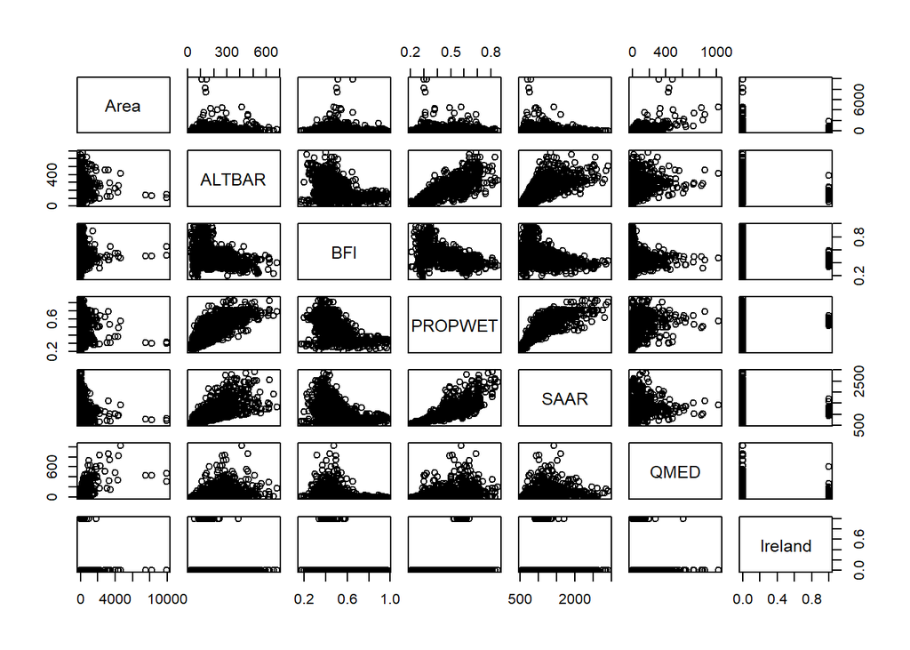

```r
ukrivers <- read.csv("ukrivers.csv",header=TRUE)
plot(ukrivers[,6:12])
```

La prima variabile che si può pensare essere importante per spiegare `QMED` è `Area`: fiumi che drenano aree molto grandi tenderanno ad avere portate più grandi:

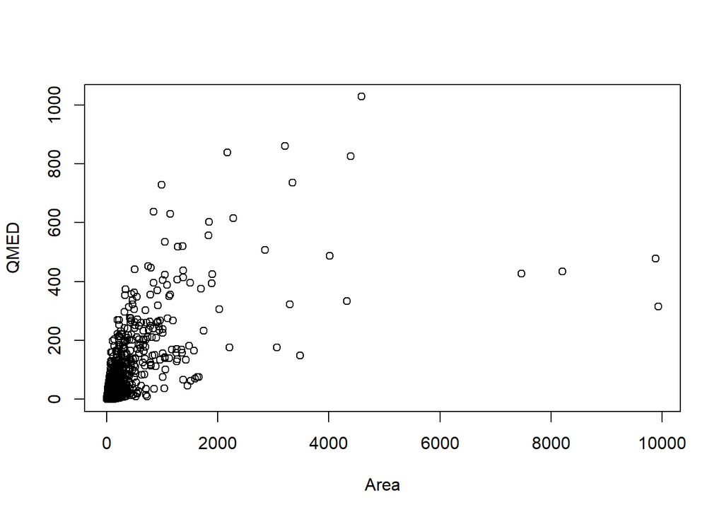

```r
plot(QMED~Area, data = ukrivers)
```

La relazione sembra essere positiva ma si nota un forte variabilità per entrambe le variabili. Inoltre i residui di un modello lineare semplice in cui si usa `Area` come predittore per `QMED` presentano una forte asimmetricità:

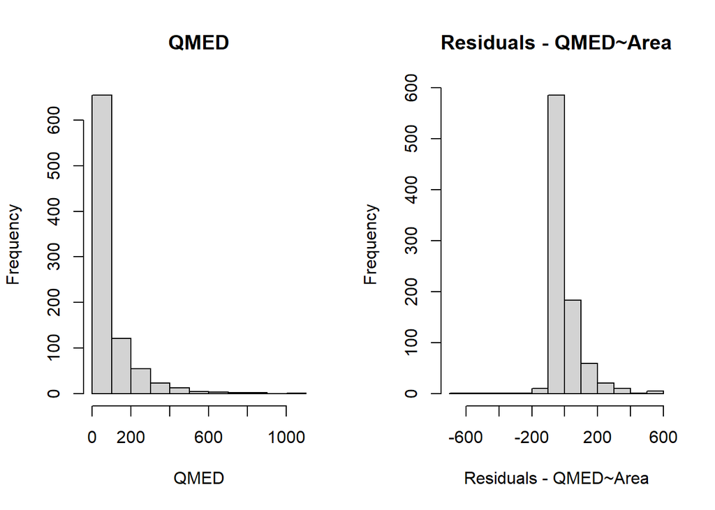

```r
par(mfrow=c(1,2))
hist(ukrivers$QMED, main = "QMED",xlab = "QMED")
hist(residuals(lm(QMED~Area, data = ukrivers)), xlab = "Residuals - QMED~Area", main = "Residuals - QMED~Area")
```

Potrebbe essere possibile aggiungere variabili esplicative al modello che riducano la asimmetricità dei residui, vediamo cosa succede se aggiungiamo tutte le variabili predittive (sensate) al modello:

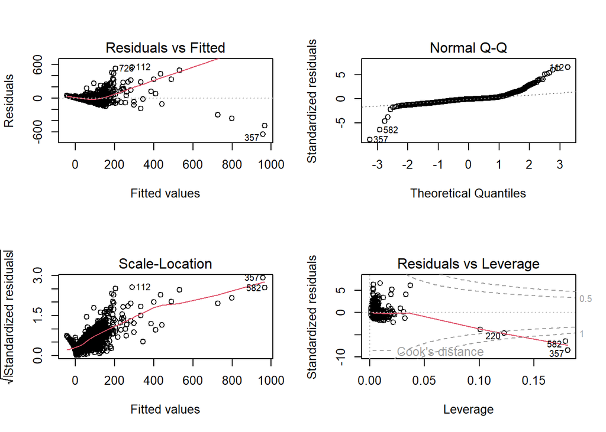

```r
par(mfrow=c(2,2))
plot(lm(QMED~Area+BFI+PROPWET+SAAR, data = ukrivers))
```

I residui presentano forti problematiche legate alla non-linearità della relazione tra le variabili predittive e `QMED` e di eteroschedasticità e in generale la variabile `QMED` presenta valori molto grandi per alcune osservazioni. Invece che modellare la variabile così com’è useremo quindi il suo logaritmo:

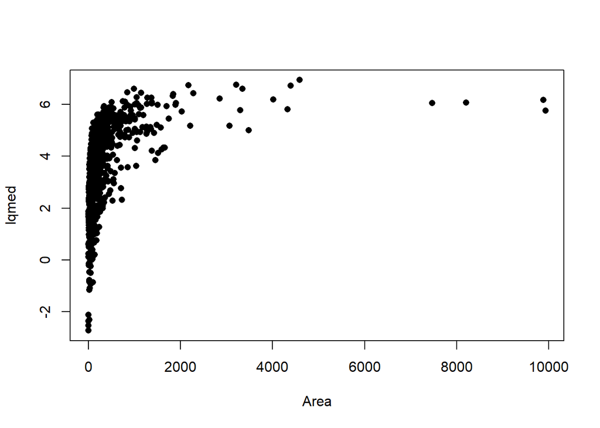

```r
tukrivers <- ukrivers
tukrivers$lqmed <- log(tukrivers$QMED)
plot(lqmed~Area, data = tukrivers,pch=16)
```

La relazione tra Area e `lqmed` sembra essere non-lineare - usiamo quindi la trasformazione logaritmica anche sulla variabile `Area`:

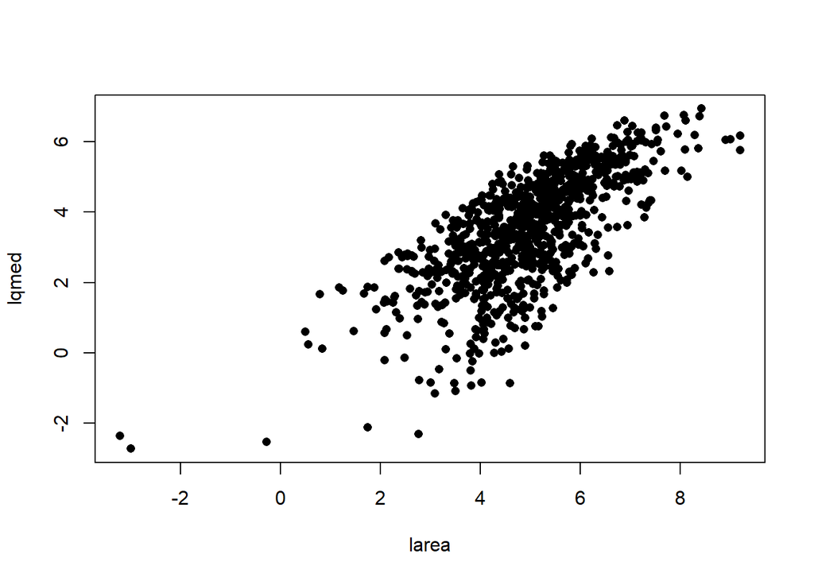

```r
tukrivers$larea <- log(tukrivers$Area)
plot(lqmed~larea, data = tukrivers,pch=16)
```

e notiamo che ora la relazione sembra essere lineare e più regolare. Il modello di partenza è
$$\text{lqmed}_i =
\beta_0 + \beta_1 \text{larea} + \epsilon_i$$

Una prima occhiata ai residui sembra indicare che vi è ancora abbastanza asimmetria nei residui:

```r
lfit0 <- lm(lqmed ~ larea, data = tukrivers)
summary(lfit0)
```

```
##
## Call:
## lm(formula = lqmed ~ larea, data = tukrivers)
##
## Residuals:
##     Min      1Q  Median      3Q     Max
## -4.0444 -0.6599  0.2328  0.8038  2.0794
##
## Coefficients:
##             Estimate Std. Error t value Pr(>|t|)
## (Intercept) -0.64486    0.13936  -4.627 4.26e-06 ***
## larea        0.83125    0.02727  30.481  < 2e-16 ***
## ---
## Signif. codes:  0 '***' 0.001 '**' 0.01 '*' 0.05 '.' 0.1 ' ' 1
##
## Residual standard error: 1.106 on 880 degrees of freedom
## Multiple R-squared:  0.5136, Adjusted R-squared:  0.513
## F-statistic: 929.1 on 1 and 880 DF,  p-value: < 2.2e-16
```

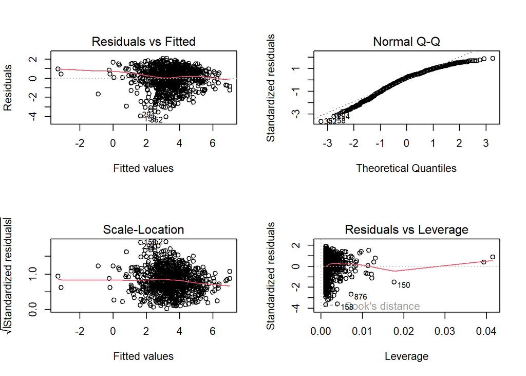

```r
par(mfrow=c(2,2))
plot(lfit0)
```

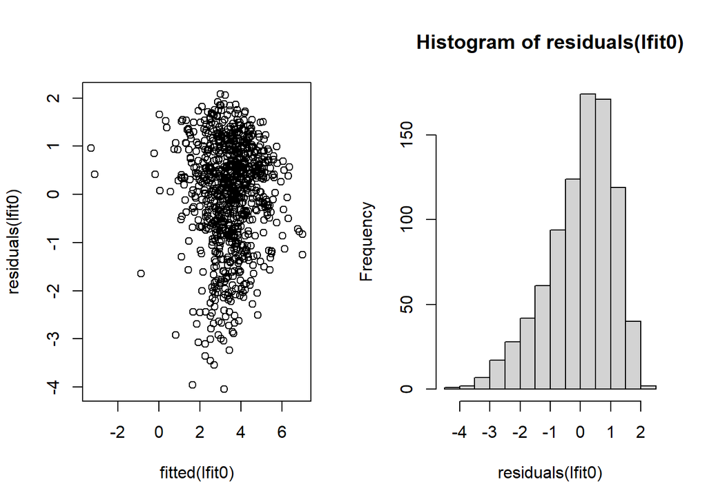

```r
par(mfrow=c(1,2))
plot(fitted(lfit0), residuals(lfit0))
hist(residuals(lfit0))
```

## Che trasformazione per la variabile risposta?

Si noti che usando la trasformazione di boxcox si sarebbe scelta un’altra trasformazione, rispetto alla trasformazione logaritmica.

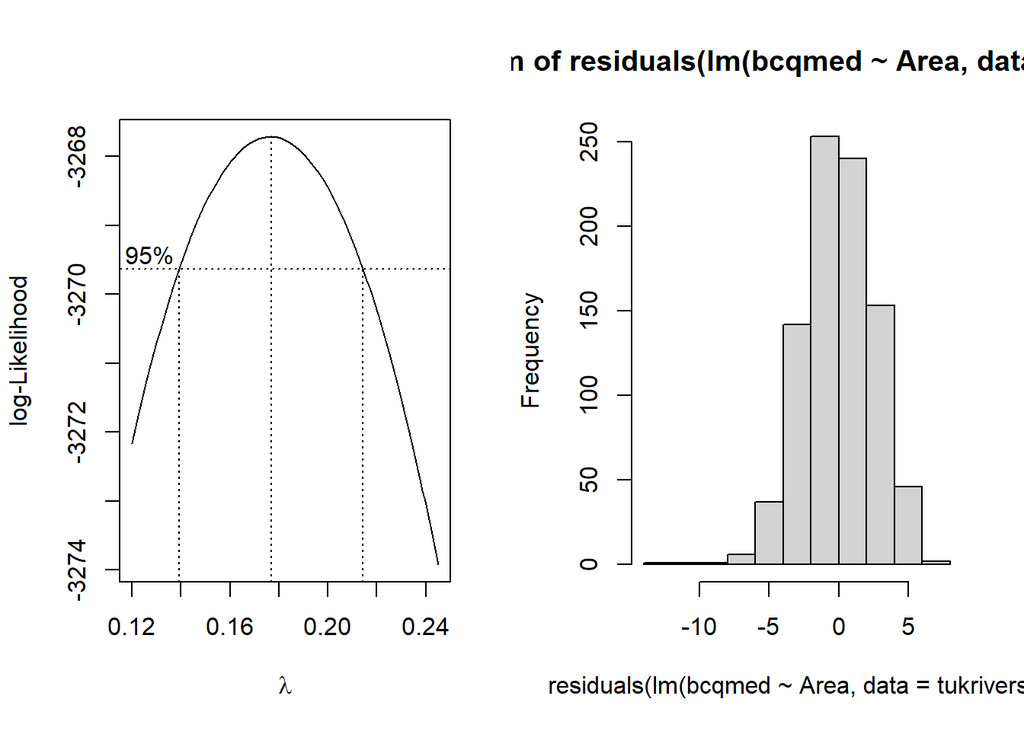

```r
par(mfrow=c(1,2))
bc0 <- MASS::boxcox(lm(QMED~Area, data = ukrivers), lambda = seq(0.12,0.25,by=0.025))
## potremmo ad esempio scegliere lambda = 0.18
tukrivers$bcqmed <- (ukrivers$QMED^0.18-1)/0.18
hist(residuals(lm(bcqmed ~ Area, data = tukrivers)))
```

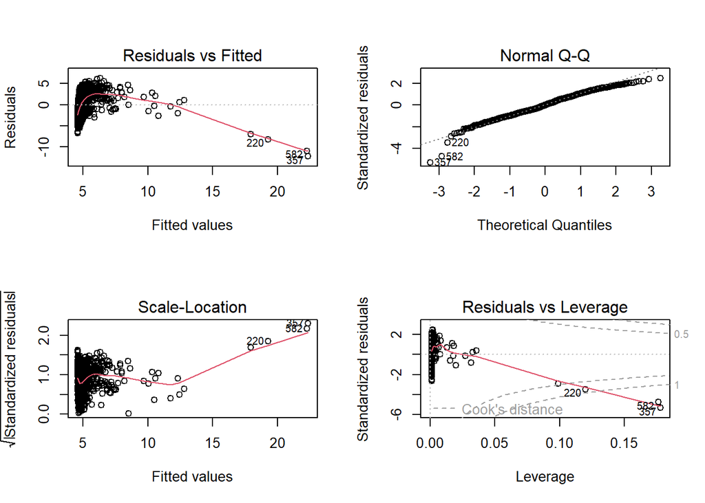

```r
par(mfrow=c(2,2))
plot(lm(bcqmed ~ Area, data = tukrivers))
```

La trasformazione logaritmica ha il vantaggio di permettere di predire valori della variabile originale usando un modello moltiplicativo facile da implementare e da comunicare agli utenti del modello. Una volta finita la fase di costruzione del modello si potrebbe tornare a valutare la scelta della trasformazione usata per la variabile risposta.

# Trasformazioni delle variabili esplicative

Il prossimo passo per la costruzione del modello è di tentare di aggiungere variabili esplicative e vedere se spiegano parte della variabilità residua. Si potrebbe per esempio usare un algoritmo backward o foreward per selezionare le variabili che più migliorano il BIC. Dato che la relazione tra le variabili predittive a la risposta dovrebbe essere (secondo le assunzioni del modello) lineare, potrebbe essere opportuno pensare in primo luogo se conviene inserire le variabili così come sono nell’algoritmo e se sarebbe invece opportuno trasformare queste variabili per rendere la relazione tra le variabili stesse e la variabile dipendente (o i residui del modello base) più lineari.

Andando in ordine di variabile del dataset:

- ALTBAR

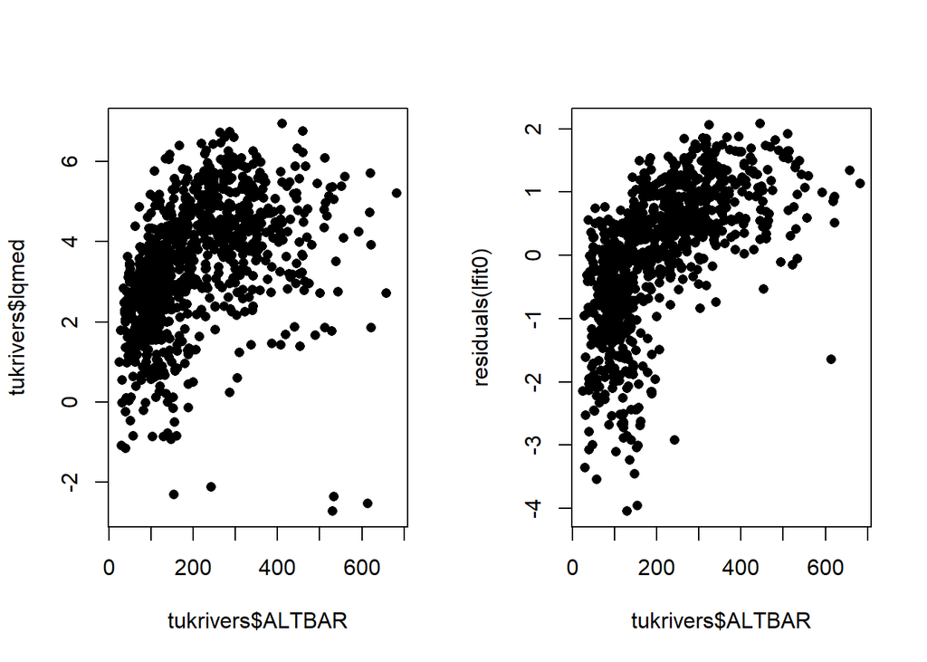

```r
par(mfrow=c(1,2), pch = 16)
plot(tukrivers$ALTBAR, tukrivers$lqmed)
plot(tukrivers$ALTBAR, residuals(lfit0))
```

Vi è una chiara non-linearità nella relazione tra `ALTBAR` e `lqmed`, che potrebbe essere risolta usando una trasformazione logaritmica di `ALTBAR` o usando la radice quadrata di ALTBAR:

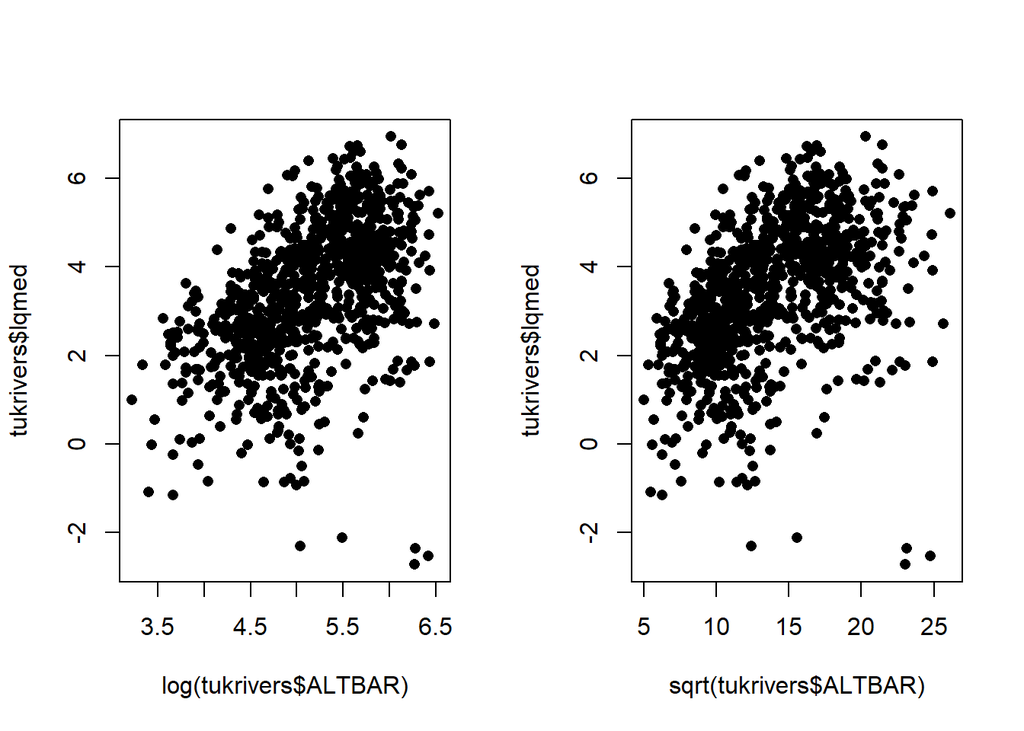

```r
par(mfrow=c(1,2), pch = 16)
plot(log(tukrivers$ALTBAR), tukrivers$lqmed)
plot(sqrt(tukrivers$ALTBAR), tukrivers$lqmed)
```

Prendiamo la trasformazione logaritmica che risulta in una relazione più lineare e ha inoltre il vantaggio interpretativo (la scelta della radice quadrata sarebbe accettabile):

```r
tukrivers$laltbar <- log(tukrivers$ALTBAR)
```

- BFI

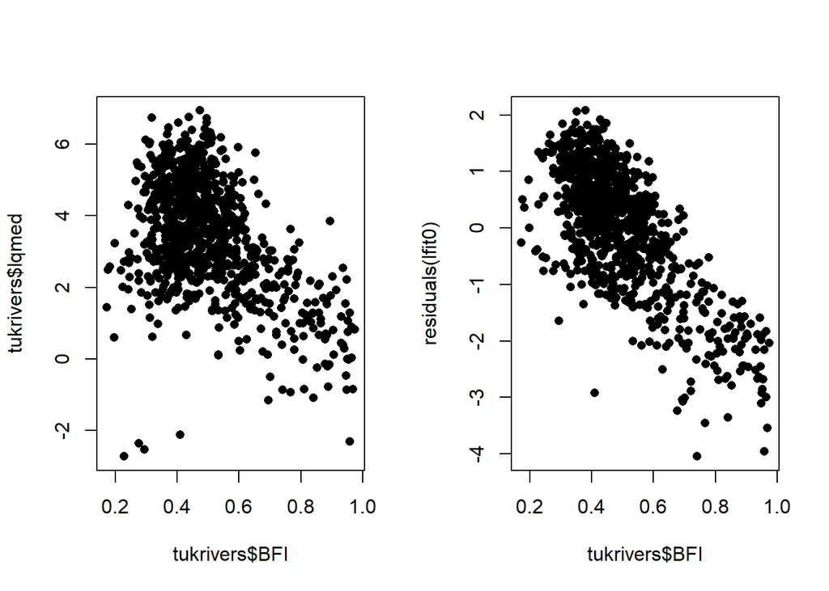

```r
par(mfrow=c(1,2), pch = 16)
plot(tukrivers$BFI, tukrivers$lqmed)
plot(tukrivers$BFI, residuals(lfit0))
```

Vi è una chiara non-linearità nella relazione tra `ALTBAR` e `lqmed`, e una forte relazione abbastanza lineare tra BFI e i residui del modello iniziale. Sembra che inserire BFI nel modello possa spiegare parte della variabilità dei dati e forse la relazione dovrà essere inserita usando anche trasformazioni polinomiali di BFI, dato che la forma relazionale tra `BFI` e `lqmed` sembra quadratica:

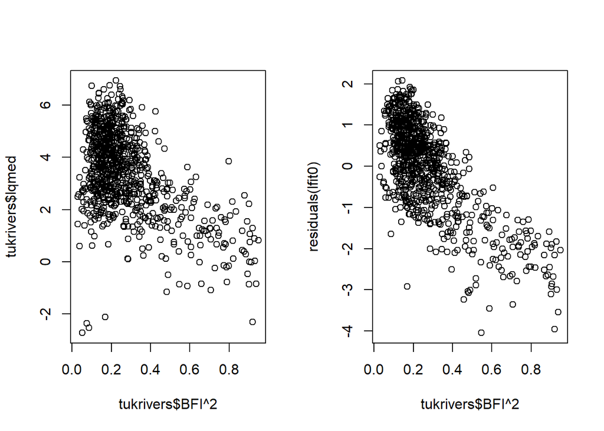

```r
par(mfrow=c(1,2))
plot(tukrivers$BFI^2, tukrivers$lqmed)
plot(tukrivers$BFI^2, residuals(lfit0))
```

Creiamo la variabile in cui trasformiamo `BFI` elevando la variabile al quadrato:

```r
tukrivers$bfisq <- (tukrivers$BFI^2)
```

Quando useremo questa variabile nel modello sarà sempre opportuno inserire anche `BFI` e non solo la trasformazione (e si potrebbe usare `I(BFI^2)`).

- PROPWET

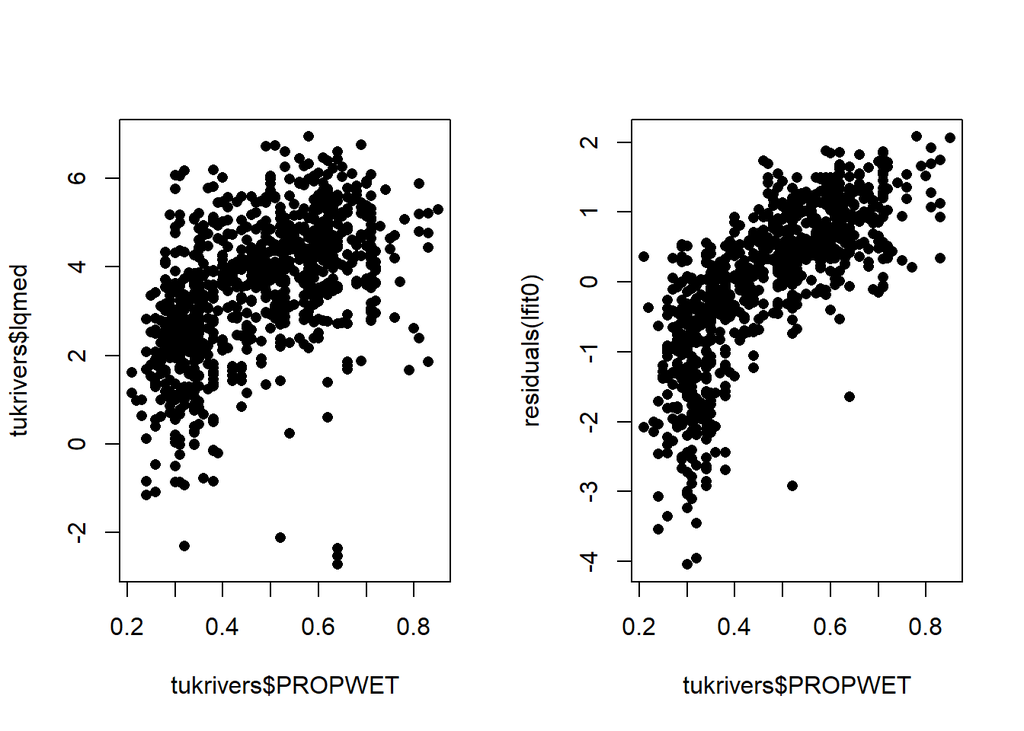

```r
par(mfrow=c(1,2), pch = 16)
plot(tukrivers$PROPWET, tukrivers$lqmed)
plot(tukrivers$PROPWET, residuals(lfit0))
```

Vi è una chiara non-linearità nella relazione tra `PROPWET` e `lqmed`, che potrebbe essere risolta usando una trasformazione logaritmica di `PROPWET`, usando la radice quadrata di `PROPWET` o anche invertendo `PROPWET`:

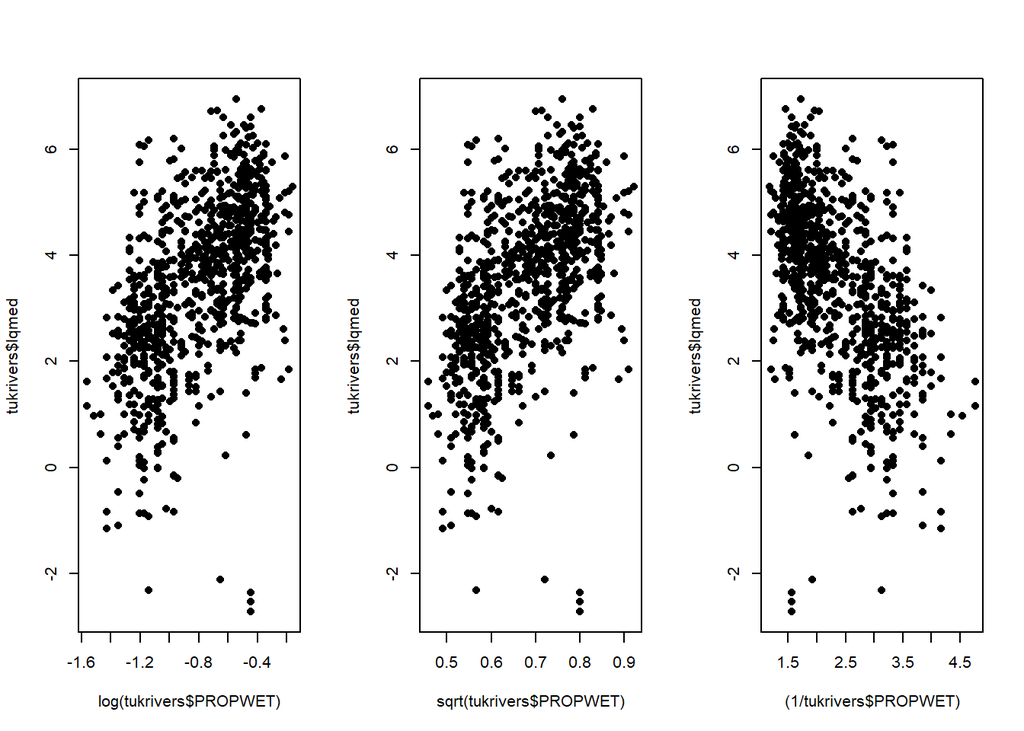

```r
par(mfrow=c(1,3), pch = 16)
plot(log(tukrivers$PROPWET), tukrivers$lqmed)
plot(sqrt(tukrivers$PROPWET), tukrivers$lqmed)
plot((1/tukrivers$PROPWET), tukrivers$lqmed)
```

Scegliamo (sempre per motivazioni di interpretazione del modello) di trasformare `PROPWET` usando la trasformazione logaritmica:

```r
tukrivers$lpropwet <- log(tukrivers$PROPWET)
```

- SAAR

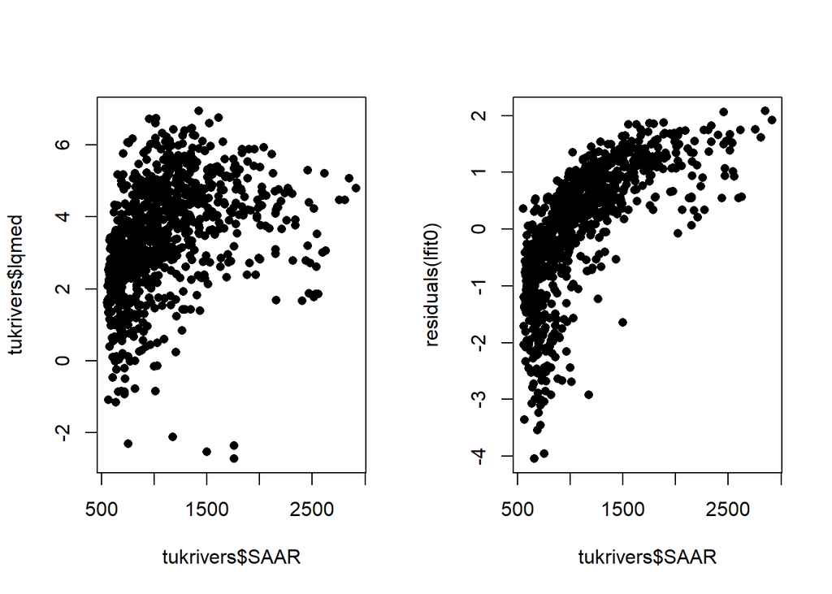

```r
par(mfrow=c(1,2), pch = 16)
plot(tukrivers$SAAR, tukrivers$lqmed)
plot(tukrivers$SAAR, residuals(lfit0))
```

Vi è una chiara non-linearità nella relazione tra `SAAR` e `lqmed`, che potrebbe essere risolta usando una trasformazione logaritmica di `SAAR` o invertendo `SAAR`:

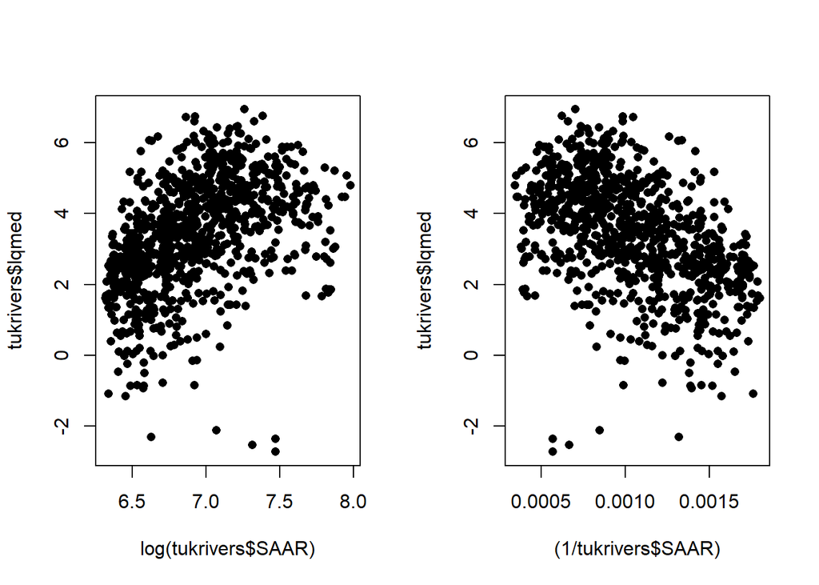

```r
par(mfrow=c(1,2), pch = 16)
plot(log(tukrivers$SAAR), tukrivers$lqmed)
plot((1/tukrivers$SAAR), tukrivers$lqmed)
```

In questo caso l’inversione sembra essere a trasformazione che rende la relazione tra `SAAR` e `lqmed` la più lineare possibile. Si noti però che i valori numerici della variabile invertita sono molto piccoli: trasformiamo quindi la variabile usando `(1000/SAAR)`, sebbene questo non cambi la relazione tra la variabile trasformata e `lqmed`:

```r
tukrivers$isaar <- (1000/tukrivers$SAAR)
```

Adesso che abbiamo scelto delle possibili trasformazioni per le variabili esplicative possiamo guardare come queste variano con la variabile dipendente e cercare di usare le variabili trasformate per selezionare un modello che sia adeguato a predire `lqmed`:

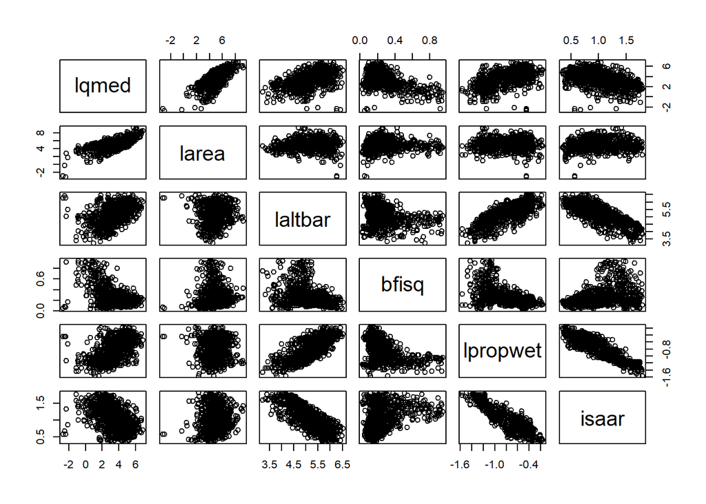

```r
plot(tukrivers[,c("lqmed","larea","laltbar","bfisq","lpropwet","isaar")])
```

## Scegliere il modello

Passiamo ora alla selezione del modello. Si provi ad usare un algoritmo a scelta sui dati originali e sui dati trasformati.

Iniziamo con un algoritmo *stepwise* basato su BIC per i dati originali.

```
## Start:  AIC=188.76
## lqmed ~ larea
##
##           Df Sum of Sq     RSS     AIC
## + PROPWET  1    610.61  465.20 -543.88
## + BFI      1    559.40  516.41 -451.77
## + SAAR     1    534.38  541.43 -410.05
## + ALTBAR   1    402.97  672.85 -218.39
## <none>                 1075.81  188.76
##
## Step:  AIC=-543.88
## lqmed ~ larea + PROPWET
##
##           Df Sum of Sq     RSS     AIC
## + BFI      1    187.24  277.96 -991.32
## + SAAR     1     22.15  443.05 -580.13
## + ALTBAR   1      6.02  459.18 -548.60
## <none>                  465.20 -543.88
## - PROPWET  1    610.61 1075.81  188.76
##
## Step:  AIC=-991.32
## lqmed ~ larea + PROPWET + BFI
##
##           Df Sum of Sq    RSS      AIC
## + SAAR     1    27.942 250.02 -1077.98
## + ALTBAR   1     3.532 274.43  -995.82
## <none>                 277.96  -991.32
## - BFI      1   187.242 465.20  -543.88
## - PROPWET  1   238.452 516.41  -451.77
##
## Step:  AIC=-1077.98
## lqmed ~ larea + PROPWET + BFI + SAAR
##
##           Df Sum of Sq    RSS      AIC
## <none>                 250.02 -1077.98
## + ALTBAR   1     0.582 249.44 -1073.26
## - PROPWET  1    25.498 275.52  -999.11
## - SAAR     1    27.942 277.96  -991.32
## - BFI      1   193.035 443.05  -580.13
```

Le variabili aggiunte al modello sono `PROPWET`, `BFI` e `SAAR`. Usiamo ora invece i dati trasformati

```
## Start:  AIC=188.76
## lqmed ~ larea
##
##            Df Sum of Sq     RSS     AIC
## + lpropwet  1    636.81  439.00 -595.01
## + isaar     1    617.66  458.15 -557.36
## + bfisq     1    578.55  497.26 -485.11
## + BFI       1    559.40  516.41 -451.77
## + laltbar   1    448.07  627.74 -279.59
## <none>                  1075.81  188.76
##
## Step:  AIC=-595.01
## lqmed ~ larea + lpropwet
##
##            Df Sum of Sq     RSS      AIC
## + bfisq     1    196.41  242.59 -1111.37
## + BFI       1    182.98  256.03 -1063.83
## + isaar     1     24.22  414.78  -638.28
## + laltbar   1      6.12  432.88  -600.61
## <none>                   439.00  -595.01
## - lpropwet  1    636.81 1075.81   188.76
##
## Step:  AIC=-1111.37
## lqmed ~ larea + lpropwet + bfisq
##
##            Df Sum of Sq    RSS      AIC
## + isaar     1    54.408 188.18 -1328.58
## + laltbar   1     7.798 234.79 -1133.40
## <none>                  242.59 -1111.37
## + BFI       1     1.290 241.30 -1109.29
## - bfisq     1   196.411 439.00  -595.01
## - lpropwet  1   254.670 497.26  -485.11
##
## Step:  AIC=-1328.58
## lqmed ~ larea + lpropwet + bfisq + isaar
##
##            Df Sum of Sq    RSS      AIC
## - lpropwet  1     0.599 188.78 -1332.56
## <none>                  188.18 -1328.58
## + BFI       1     0.462 187.72 -1323.97
## + laltbar   1     0.191 187.99 -1322.70
## - isaar     1    54.408 242.59 -1111.37
## - bfisq     1   226.600 414.78  -638.28
##
## Step:  AIC=-1332.56
## lqmed ~ larea + bfisq + isaar
##
##            Df Sum of Sq    RSS      AIC
## <none>                  188.78 -1332.56
## + lpropwet  1     0.599 188.18 -1328.58
## + BFI       1     0.378 188.40 -1327.55
## + laltbar   1     0.363 188.42 -1327.48
## - bfisq     1   269.370 458.15  -557.36
## - isaar     1   308.480 497.26  -485.11
```

Le variabili aggiunte al modello sono `bfisq` e `isaar`. Confrontiamo ora le stime ottenute nei due modelli selezionati dall’algoritmo. La prima domanda da porsi è quale dei due modelli predice meglio i dati osservati: confrontiamo quindi il grafico di dispersione di valori osservati e stimati di `lqmed`

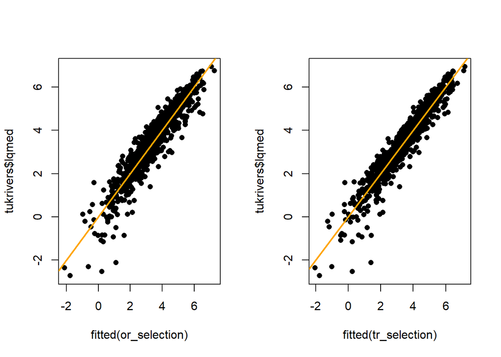

```r
par(mfrow=c(1,2),pch=16)
plot(fitted(or_selection),tukrivers$lqmed)
abline(0,1, lwd = 2, col= "orange")
plot(fitted(tr_selection),tukrivers$lqmed)
abline(0,1, lwd = 2, col= "orange")
```

In termini di $\text{RMSE}_{LOOCV}$ il modello basato sulle variabili trasformate ha una perfomance migliore:

```r
calc_loocv_rmse = function(model) {
sqrt(mean((resid(model) / (1 - hatvalues(model))) ^ 2))
}
calc_loocv_rmse(or_selection)
```

```
## [1] 0.536119
```

```r
calc_loocv_rmse(tr_selection)
```

```
## [1] 0.4654229
```

Il modello basato sulle variabili trasformate risulta anche avere un valore di BIC minore.

```r
BIC(or_selection)
```

```
## [1] 1431.805
```

```r
BIC(tr_selection)
```

```
## [1] 1177.225
```

Entrambi i modelli danno una predizione abbastanza accurata dei dati osservati. Come si comportano invece i residui dei due modelli?

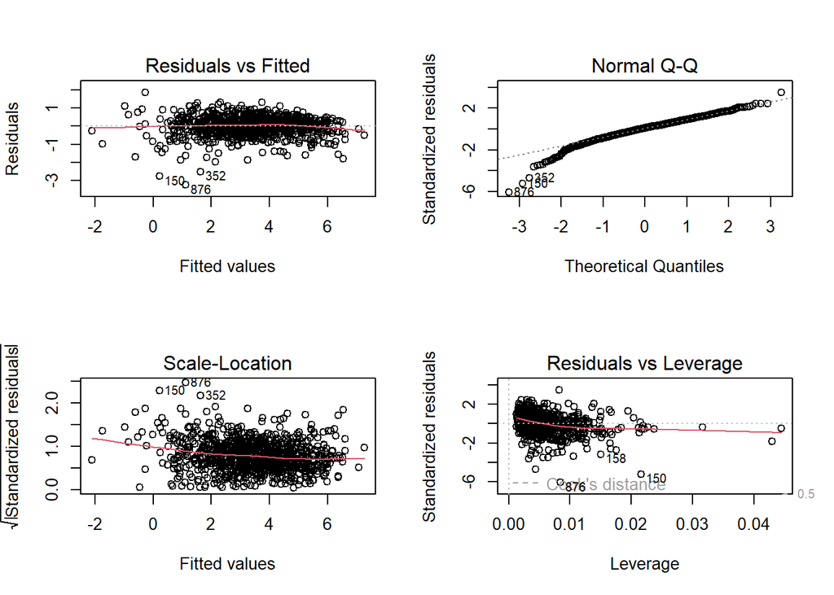

```r
par(mfrow=c(2,2))
plot(or_selection)
```

Guardiamo anche la relazione tra variabili esplicative del modello e residui:

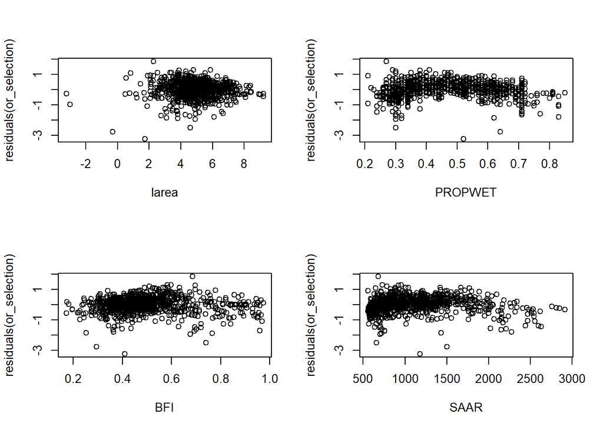

```r
#  the matrix of predictor variables
mpreds <- or_selection$model[,-1]
par(mfrow=c(2,ceiling(ncol(mpreds)/2)))
for(j in (1:ncol(mpreds))) plot(mpreds[,j], residuals(or_selection), xlab = names(mpreds)[j])
```

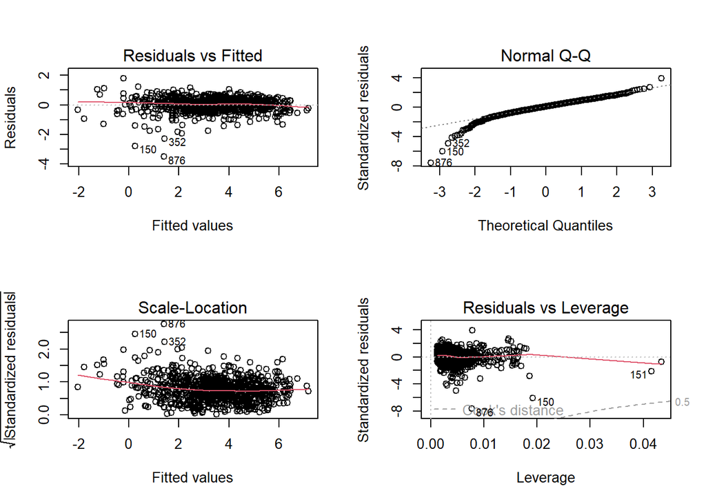

```r
par(mfrow=c(2,2))
plot(tr_selection)
```

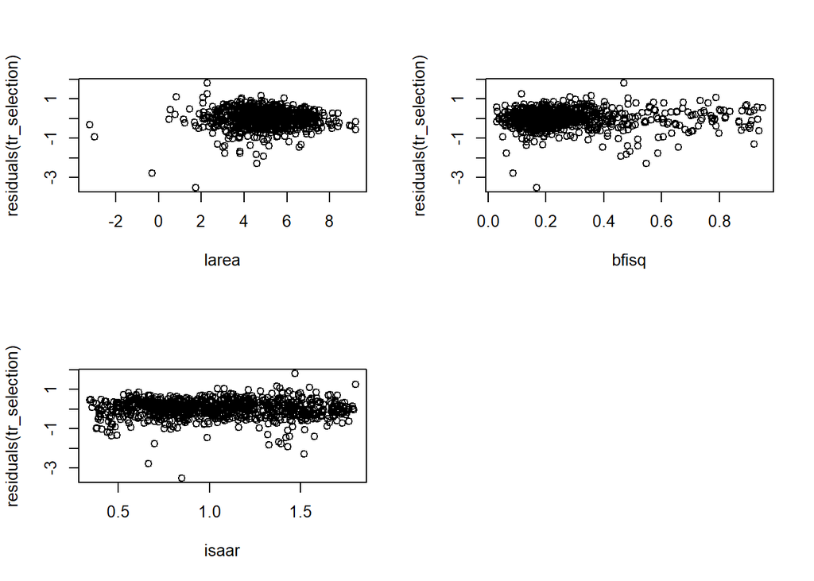

```r
# the matrix of predictor variables
mpreds <- tr_selection$model[,-1]
par(mfrow=c(2,ceiling(ncol(mpreds)/2)))
for(j in (1:ncol(mpreds))) plot(mpreds[,j], residuals(tr_selection), xlab = names(mpreds)[j])
```

Per entrambi i modelli rimangono dei problemi di asimmetria dei residui, con residui negativi e grandi in valore assoluto. Per il modello basato sulle variabili trasformate inoltre si nota che nessuna forma funzionale rimane tra le variabili predittive e i residui. In nessuno dei due modelli sembrano esserci forti segnali di eteroschedasticità: questo è dato dal fatto che abbiamo già trasformato la variabile originale (`QMED`).

Facciamo ora una verifica aggiuntiva per verificare se il modello con i predittori scelti tramite BIC presenta problemi di co-linearità

```r
car::vif(tr_selection)
```

```
##    larea    bfisq    isaar
## 1.005087 1.138931 1.142688
```

```r
## anche il grafico della relazione tra predittori
## non è problematico
# plot(tr_selection$model)
```

I valori bassi del Variance Inflation Factor indicano che le variabili non presentano problematicità legate alla co-linearità.

Infine controlliamo se esistono punti particolarmente influenti:

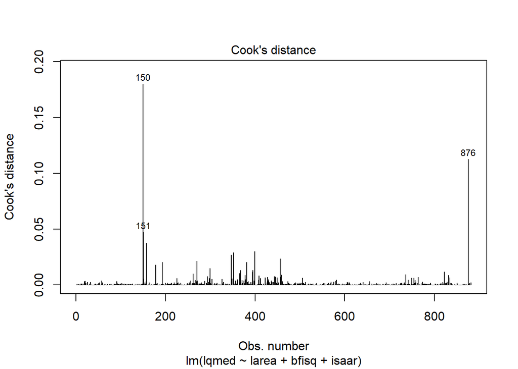

```r
par(mfrow=c(1,1))
plot(tr_selection,4)
```

```r
tr_selection$model[cooks.distance(tr_selection) > 0.03,]
```

```
##         lqmed      larea    bfisq     isaar
## 150 -2.531998 -0.2876821 0.086436 0.6671114
## 151 -2.718101 -2.9957323 0.051984 0.5691520
## 158 -2.307598  2.7631695 0.919681 1.3210040
## 876 -2.111965  1.7474592 0.168100 0.8496177
```

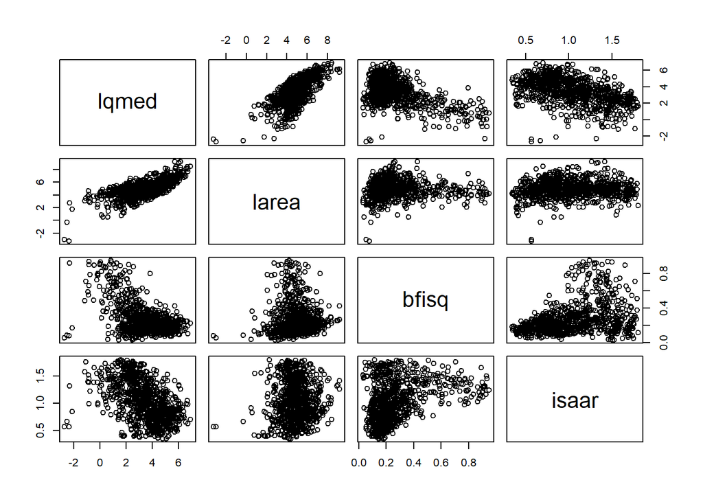

```r
plot(tr_selection$model)
```

Alcuni punti con un valore di $QMED$ particolarmente piccolo risultano avere una influenza abbastanza elevata: si potrebbe decidere di eliminare questi punti che sembrano essere anomali ma sarebbe opportuno anche verificare con un esperto di idrologia se queste stazioni hanno caratteristiche particolari. Attenzione: rimuovere questi (pochi) punti dall’analisi implicherebbe che il modello non sarebbe generalizzabile per luoghi le cui caratteristiche sono simili a quelle di queste stazioni.

Per ora manteniamo tutte le osservazioni nell’analisi.

Usando il modello di ricerca esaustiva delle variabili esplicative, si seleziona lo stesso modello scelto dalla algoritmo *stepwise* se il criterio con cui si sceglie il modello è il BIC:

```r
library(leaps)
all_mod <-summary(regsubsets(lqmed ~ larea+isaar+lpropwet+laltbar+BFI+bfisq, data = tukrivers))
all_mod$which[which.min(all_mod$bic),]
```

```
## (Intercept)       larea       isaar    lpropwet     laltbar         BFI
##        TRUE        TRUE        TRUE       FALSE       FALSE       FALSE
##       bfisq
##        TRUE
```

Segliamo come modello “finale” il modello basato sulle variabili trasformate, inserendo anche la variabile `BFI` nella sua forma originale oltre che la forma al quadrato:

```r
fit_final <- update(lm(tr_selection), .~.+BFI, data = tukrivers)
summary(fit_final)
```

```
##
## Call:
## lm(formula = lqmed ~ larea + bfisq + isaar + BFI, data = tukrivers)
##
## Residuals:
##     Min      1Q  Median      3Q     Max
## -3.5262 -0.2330  0.0300  0.2948  1.7715
##
## Coefficients:
##             Estimate Std. Error t value Pr(>|t|)
## (Intercept)  1.75538    0.15920  11.026  < 2e-16 ***
## larea        0.84767    0.01190  71.215  < 2e-16 ***
## bfisq       -3.91934    0.50108  -7.822 1.49e-14 ***
## isaar       -1.74587    0.04605 -37.914  < 2e-16 ***
## BFI          0.77979    0.58759   1.327    0.185
## ---
## Signif. codes:  0 '***' 0.001 '**' 0.01 '*' 0.05 '.' 0.1 ' ' 1
##
## Residual standard error: 0.4635 on 877 degrees of freedom
## Multiple R-squared:  0.9148, Adjusted R-squared:  0.9144
## F-statistic:  2355 on 4 and 877 DF,  p-value: < 2.2e-16
```

```r
anova(lfit0, fit_final)
```

```
## Analysis of Variance Table
##
## Model 1: lqmed ~ larea
## Model 2: lqmed ~ larea + bfisq + isaar + BFI
##   Res.Df    RSS Df Sum of Sq      F    Pr(>F)
## 1    880 1075.8
## 2    877  188.4  3    887.41 1376.9 < 2.2e-16 ***
## ---
## Signif. codes:  0 '***' 0.001 '**' 0.01 '*' 0.05 '.' 0.1 ' ' 1
```

Controlliamo anche che le variabili (trasformate) escluse dal modello non varino in maniera sistematica con i residui del modello:

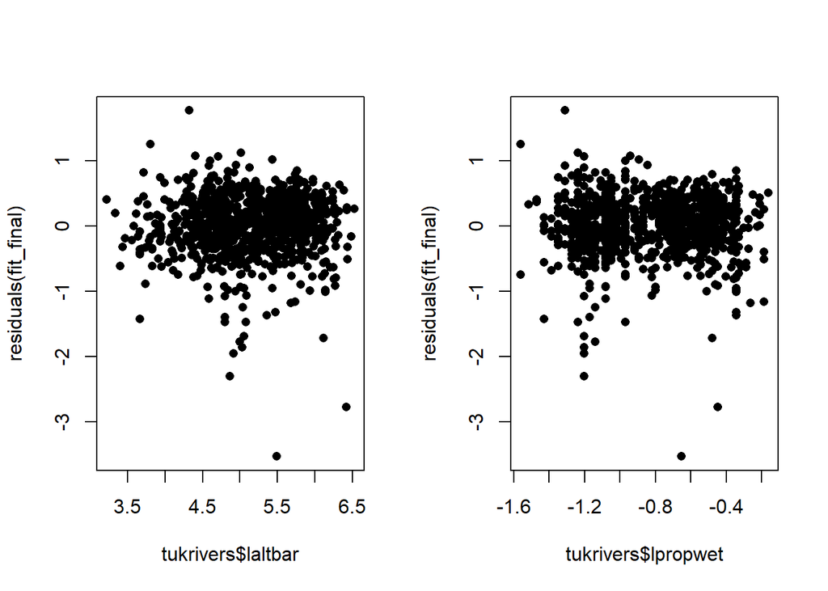

```r
par(mfrow=c(1,2), pch = 16)
plot(tukrivers$laltbar, residuals(fit_final))
plot(tukrivers$lpropwet, residuals(fit_final))
```

Non si nota nessuna forte relazione tra le variabili non inserite nel modello e i residui.

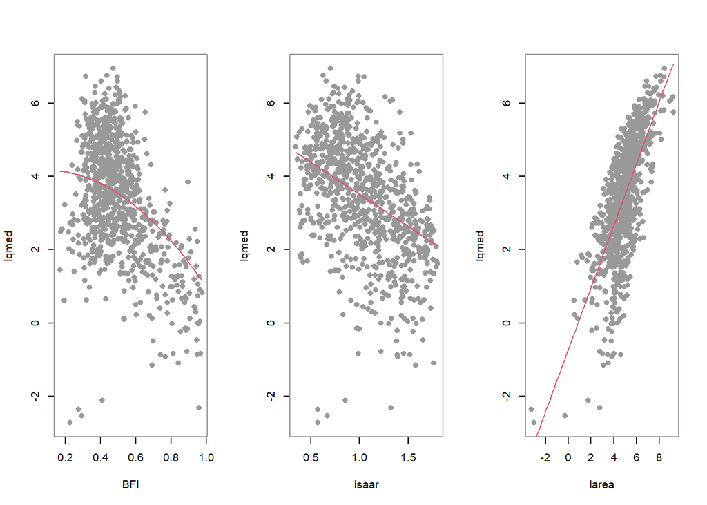

```r
par(mfrow=c(1,3), pch=16,col="grey60")
lout <- 100
nd <- data.frame(isaar = rep(mean(tukrivers$isaar), lout),
                 larea = rep(mean(tukrivers$larea), lout),
                 BFI = seq(min(tukrivers$BFI), max(tukrivers$BFI), length.out = lout),
                 bfisq = seq(min(tukrivers$BFI), max(tukrivers$BFI), length.out = lout)^2)
plot(lqmed ~ BFI, data = tukrivers)
lines(nd$BFI, predict(fit_final, newdata = nd), col = 2)
nd <- data.frame(isaar = seq(min(tukrivers$isaar), max(tukrivers$isaar), length.out = lout),
                 BFI = rep(mean(tukrivers$BFI), lout),
                 bfisq = rep(mean(tukrivers$bfisq), lout),
                 larea = rep(mean(tukrivers$larea), lout))
plot(lqmed ~ isaar, data = tukrivers)
lines(nd$isaar, predict(fit_final, newdata = nd), col = 2)
nd <- data.frame(isaar = rep(mean(tukrivers$isaar), lout),
                 BFI = rep(mean(tukrivers$BFI), lout),
                 bfisq = rep(mean(tukrivers$bfisq), lout),
                 larea = seq(min(tukrivers$larea), max(tukrivers$larea), length.out = lout))
plot(lqmed ~ larea, data = tukrivers)
lines(nd$larea, predict(fit_final, newdata = nd), col = 2)
```

Ci potrebbe invece essere qualche problema legato all’indipendenza delle osservazioni: il comportamento dei fiumi è in gran parte caratterizzato da fenomeni geo-morfologici e climatologici che agiscono su larga scale, ed è quindi possibile che due stazioni siano correlate l’una all’altra perché impattate dagli stessi processi esogeni. Inoltre alcune delle stazioni misurano lo stesso fiume in punti diversi: la portata di un fiume è sicuramente correlata con la misurazione fatta in un altro punto. Nel modello lineare multiplo classico non vi è modo di tenere in considerazione questa correlazione tra osservazioni e questo può risultare in stime non corrette della varianza (del modello e dei predittori). Esistono metodologie che permettono di apportare correzioni che tengano conto della correlazione tra osservazioni, ma queste non vengono discusse in questo caso studio/corso.

La cosa diventa evidente anche guardando la mappa dei valori stimati:

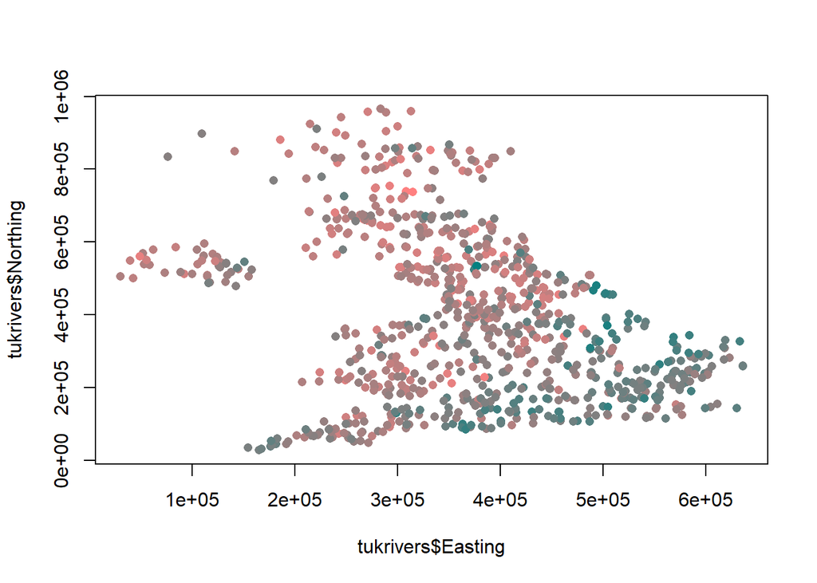

```r
par(mfrow=c(1,1), pch = 16)
pp <- predict(fit_final)
## creiamo una variabile che dipenda dal valore stiamto di lqmed
ppcol <- rgb((pp-min(pp)+0.1)/(max(pp)-min(pp)+0.1), 0.5,0.5)
plot(tukrivers$Easting, tukrivers$Northing,
     col = ppcol)
```

Il modello finale che è stato selezionato è un modello applicato ad una trasformazione della variabile originale: non è possibile traslare in maniera diretta l’inferenza fatta per la variabile trasformata alla variabile originale. Tuttavia, dato che è stata usata la trasformazione logaritmica è possibile dire che un modello valido per la mediana della variabile originale è un modello moltiplicativo basato sulle variabili predittive anch’esse trasformate.